# transformer

```python
import math
import torch
from torch import nn
from torch.utils.data import Dataset, DataLoader
import torch.optim as optim
import matplotlib.pyplot as plt
import seaborn as sns
import random
from sklearn.decomposition import PCA
from sklearn.manifold import TSNE


class PositionWiseFFN(nn.Module):
    """Positionwise feed-forward network."""
    def __init__(self, ffn_num_input, ffn_num_hiddens, ffn_num_outputs):
        super().__init__()
        self.dense1 = nn.Linear(ffn_num_input, ffn_num_hiddens)
        self.relu = nn.ReLU()
        self.dense2 = nn.Linear(ffn_num_hiddens, ffn_num_outputs)

    def forward(self, X):
        return self.dense2(self.relu(self.dense1(X)))

class AddNorm(nn.Module):
    """Residual connection followed by layer normalization."""
    def __init__(self, normalized_shape, dropout):
        super().__init__()
        self.dropout = nn.Dropout(dropout)
        self.ln = nn.LayerNorm(normalized_shape)

    def forward(self, X, Y):
        return self.ln(self.dropout(Y) + X)

def create_padding_mask(valid_lens, max_len):
    """Converts valid lengths into a boolean mask for PyTorch attention."""
    if valid_lens is None:
        return None
    batch_size = valid_lens.shape[0]
    positions = torch.arange(max_len, device=valid_lens.device).expand(batch_size, max_len)
    return positions >= valid_lens.unsqueeze(1)

class PositionalEncoding(nn.Module):
    """Adds positional information since Transformers have no recurrence."""
    def __init__(self, num_hiddens, dropout, max_len=1000):
        super().__init__()
        self.dropout = nn.Dropout(dropout)
        self.P = torch.zeros((1, max_len, num_hiddens))
        X = torch.arange(max_len, dtype=torch.float32).reshape(-1, 1) / torch.pow(
            10000, torch.arange(0, num_hiddens, 2, dtype=torch.float32) / num_hiddens)
        self.P[:, :, 0::2] = torch.sin(X)
        self.P[:, :, 1::2] = torch.cos(X)

    def forward(self, X):
        X = X + self.P[:, :X.shape[1], :].to(X.device)
        return self.dropout(X)

# --- 2. Transformer Components ---

class EncoderBlock(nn.Module):
    def __init__(self, num_hiddens, norm_shape, ffn_num_input, ffn_num_hiddens, num_heads, dropout):
        super().__init__()
        self.attention = nn.MultiheadAttention(num_hiddens, num_heads, dropout=dropout, batch_first=True)
        self.addnorm1 = AddNorm(norm_shape, dropout)
        self.ffn = PositionWiseFFN(ffn_num_input, ffn_num_hiddens, num_hiddens)
        self.addnorm2 = AddNorm(norm_shape, dropout)

    def forward(self, X, valid_lens):
        mask = create_padding_mask(valid_lens, X.shape[1])
        attn_out, weights = self.attention(X, X, X, key_padding_mask=mask, average_attn_weights=False)
        Y = self.addnorm1(X, attn_out)
        return self.addnorm2(Y, self.ffn(Y)), weights

class TransformerEncoder(nn.Module):
    def __init__(self, vocab_size, num_hiddens, norm_shape, ffn_num_input, ffn_num_hiddens, num_heads, num_layers, dropout):
        super().__init__()
        self.embedding = nn.Embedding(vocab_size, num_hiddens)
        self.pos_encoding = PositionalEncoding(num_hiddens, dropout)
        self.blks = nn.ModuleList([EncoderBlock(num_hiddens, norm_shape, ffn_num_input, ffn_num_hiddens, num_heads, dropout)
                                   for _ in range(num_layers)])

    def forward(self, X, valid_lens):
        X = self.pos_encoding(self.embedding(X) * math.sqrt(X.shape[-1]))
        self.attention_weights = []
        for blk in self.blks:
            X, weights = blk(X, valid_lens)
            self.attention_weights.append(weights)
        return X

class DecoderBlock(nn.Module):
    def __init__(self, num_hiddens, norm_shape, ffn_num_input, ffn_num_hiddens, num_heads, dropout, i):
        super().__init__()
        self.i = i
        self.attention1 = nn.MultiheadAttention(num_hiddens, num_heads, dropout=dropout, batch_first=True)
        self.addnorm1 = AddNorm(norm_shape, dropout)
        self.attention2 = nn.MultiheadAttention(num_hiddens, num_heads, dropout=dropout, batch_first=True)
        self.addnorm2 = AddNorm(norm_shape, dropout)
        self.ffn = PositionWiseFFN(ffn_num_input, ffn_num_hiddens, num_hiddens)
        self.addnorm3 = AddNorm(norm_shape, dropout)

    def forward(self, X, state):
        enc_outputs, enc_valid_lens = state

        # Causal mask must be applied during BOTH training and inference
        mask = nn.Transformer.generate_square_subsequent_mask(X.shape[1]).to(X.device)

        # Standard self-attention
        X2, self_weights = self.attention1(X, X, X, attn_mask=mask, average_attn_weights=False)
        Y = self.addnorm1(X, X2)

        # Cross-attention to encoder outputs
        enc_mask = create_padding_mask(enc_valid_lens, enc_outputs.shape[1])
        Y2, cross_weights = self.attention2(Y, enc_outputs, enc_outputs, key_padding_mask=enc_mask, average_attn_weights=False)
        Z = self.addnorm2(Y, Y2)

        return self.addnorm3(Z, self.ffn(Z)), state, self_weights, cross_weights

class TransformerDecoder(nn.Module):
    def __init__(self, vocab_size, num_hiddens, norm_shape, ffn_num_input, ffn_num_hiddens, num_heads, num_layers, dropout):
        super().__init__()
        self.num_layers = num_layers
        self.embedding = nn.Embedding(vocab_size, num_hiddens)
        self.pos_encoding = PositionalEncoding(num_hiddens, dropout)
        self.blks = nn.ModuleList([DecoderBlock(num_hiddens, norm_shape, ffn_num_input, ffn_num_hiddens, num_heads, dropout, i)
                                   for i in range(num_layers)])
        self.dense = nn.Linear(num_hiddens, vocab_size)

    def init_state(self, enc_outputs, enc_valid_lens):
        return (enc_outputs, enc_valid_lens)

    def forward(self, X, state):
        X = self.pos_encoding(self.embedding(X) * math.sqrt(X.shape[-1]))
        self.attention_weights = [[], []]
        for blk in self.blks:
            X, state, self_w, cross_w = blk(X, state)
            self.attention_weights[0].append(self_w)
            self.attention_weights[1].append(cross_w)
        return self.dense(X), state

class EncoderDecoder(nn.Module):
    def __init__(self, encoder, decoder):
        super().__init__()
        self.encoder = encoder
        self.decoder = decoder

    def forward(self, enc_X, dec_X, enc_valid_lens):
        enc_outputs = self.encoder(enc_X, enc_valid_lens)
        state = self.decoder.init_state(enc_outputs, enc_valid_lens)
        return self.decoder(dec_X, state)


class ArithmeticDataset(Dataset):
    def __init__(self, num_samples):
        self.vocab = ['<PAD>', '<BOS>', '<EOS>', '+', '-', '0', '1', '2', '3', '4', '5', '6', '7', '8', '9']
        self.char2idx = {c: i for i, c in enumerate(self.vocab)}
        self.idx2char = {i: c for c, i in self.char2idx.items()}
        self.src, self.tgt_in, self.tgt_out, self.vlens = [], [], [], []

        for _ in range(num_samples):
            a, b = random.randint(0, 99), random.randint(0, 99)

            is_add = random.random() > 0.5
            eq = f"{a}+{b}" if is_add else f"{a}-{b}"
            res = a + b if is_add else a - b

            # REVERSAL TRICK: "39" becomes "93"
            ans = str(res)[::-1]

            s = [self.char2idx[c] for c in eq] + [self.char2idx['<EOS>']]
            ti = [self.char2idx['<BOS>']] + [self.char2idx[c] for c in ans]
            to = [self.char2idx[c] for c in ans] + [self.char2idx['<EOS>']]
            self.src.append(torch.tensor(s + [0]*(10-len(s))))
            self.tgt_in.append(torch.tensor(ti + [0]*(6-len(ti))))
            self.tgt_out.append(torch.tensor(to + [0]*(6-len(to))))
            self.vlens.append(len(s))

    def __len__(self): return len(self.src)
    def __getitem__(self, i): return self.src[i], self.tgt_in[i], self.tgt_out[i], self.vlens[i]


def visualize_embeddings(encoder, dataset):
    pca = PCA(n_components=2)
    embeds = pca.fit_transform(encoder.embedding.weight.detach().cpu().numpy())
    plt.figure(figsize=(8, 6))
    plt.scatter(embeds[:, 0], embeds[:, 1], c='lightblue', s=100)
    for i, t in dataset.idx2char.items():
        plt.annotate(t, (embeds[i, 0], embeds[i, 1]), fontsize=12, ha='center')
    plt.title("Learned Embedding Space (PCA)")
    plt.show()


def visualize_embeddings_tsne(encoder, dataset):
    # Perplexity must be less than the number of vocab items
    tsne = TSNE(n_components=2, perplexity=5, random_state=42)
    embeds = tsne.fit_transform(encoder.embedding.weight.detach().cpu().numpy())

    plt.figure(figsize=(8, 6))
    plt.scatter(embeds[:, 0], embeds[:, 1], c='lightgreen', s=100)
    for i, t in dataset.idx2char.items():
        plt.annotate(t, (embeds[i, 0], embeds[i, 1]), fontsize=12, ha='center')
    plt.title("Learned Embedding Space (t-SNE)")
    plt.show()


def show_attn(weights, x_tok, y_tok, title):
    weights = weights.detach().cpu().numpy()
    fig, axes = plt.subplots(1, weights.shape[0], figsize=(15, 4))
    for i in range(weights.shape[0]):
        sns.heatmap(weights[i], ax=axes[i], xticklabels=x_tok, yticklabels=y_tok, cmap='viridis')
        axes[i].set_title(f"Head {i+1}")
    plt.suptitle(title)
    plt.tight_layout()
    plt.show()
```

### Encoder Self-Attention (net.encoder.attention_weights):

Shows how the input tokens interact. Will see columns or rows lighting up where the + token pays attention to the digits around it, gathering the context of the two operands.

### Decoder Cross-Attention (net.decoder.attention_weights):

The Y-axis is the output generated so far (`<BOS>`, 9, 3), and the X-axis is the input equation (1, 4, +, 2, 5).

```python
device = torch.device('cuda' if torch.cuda.is_available() else 'cpu')
num_hiddens, num_layers, dropout, batch_size, lr, epochs = 64, 3, 0.1, 128, 0.001, 300

dataset = ArithmeticDataset(30000)
loader = DataLoader(dataset, batch_size=batch_size, shuffle=True)

vocab_size = len(dataset.vocab)

net = EncoderDecoder(TransformerEncoder(vocab_size, 32, [32], 32, 64, 4, 2, 0.1),
                     TransformerDecoder(vocab_size, 32, [32], 32, 64, 4, 2, 0.1)).to(device)

opt = optim.Adam(net.parameters(), lr=lr)
loss_fn = nn.CrossEntropyLoss(ignore_index=0)
```

```
Training...
```

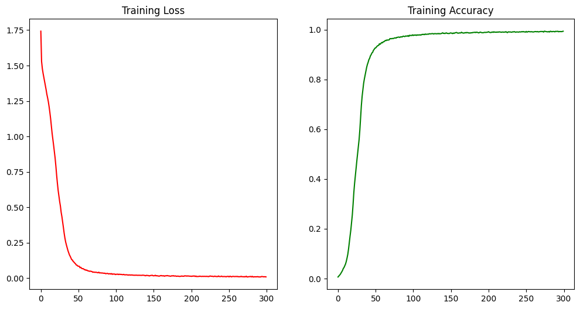

```python
epoch_losses = []
epoch_accuracies = []

print("Training...")
for epoch in range(epochs):
    epoch_loss = 0
    correct_predictions = 0
    total_predictions = 0

    for s, ti, to, vl in loader:
        s, ti, to, vl = s.to(device), ti.to(device), to.to(device), vl.to(device)
        opt.zero_grad()
        out, _ = net(s, ti, vl)
        loss = loss_fn(out.reshape(-1, vocab_size), to.reshape(-1))

        predictions = out.argmax(dim=-1)
        mask = (to != 0)
        correct = ((predictions == to) | ~mask).all(dim=1).sum().item()
        correct_predictions += correct
        total_predictions += s.size(0)
        epoch_loss += loss.item()

        loss.backward()

        torch.nn.utils.clip_grad_norm_(net.parameters(), max_norm=1.0)
        opt.step()

    epoch_losses.append(epoch_loss / len(loader))
    epoch_accuracies.append(correct_predictions / total_predictions)

plt.figure(figsize=(12, 6))
plt.subplot(1, 2, 1)
plt.plot(epoch_losses, label="Cross Entropy Loss", color="red")
plt.title("Training Loss")
plt.subplot(1, 2, 2)
plt.plot(epoch_accuracies, label="Exact Match Accuracy", color="green")
plt.title("Training Accuracy")
plt.show()
```

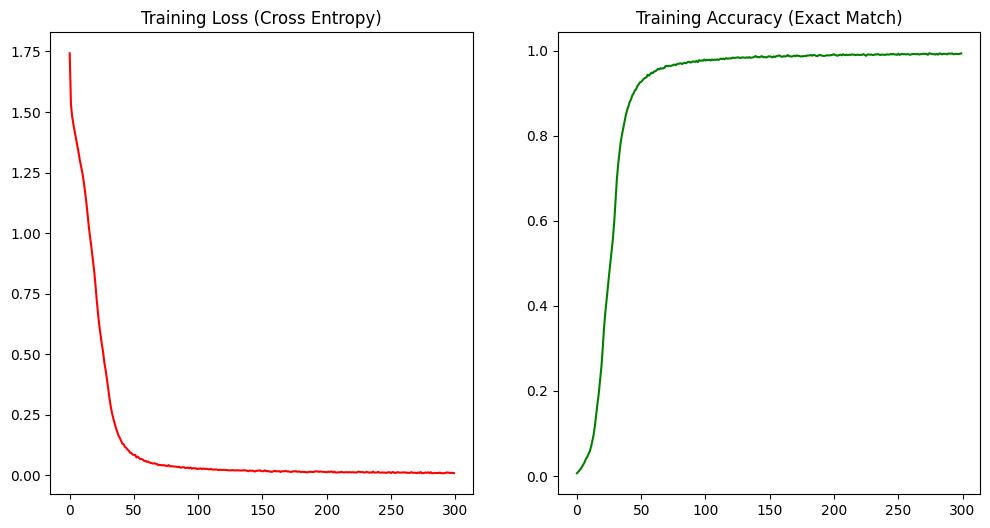

```python
plt.figure(figsize=(12, 6))
plt.subplot(1, 2, 1)
plt.plot(epoch_losses, label="Cross Entropy Loss", color="red")
plt.title("Training Loss (Cross Entropy)")
plt.subplot(1, 2, 2)
plt.plot(epoch_accuracies, label="Exact Match Accuracy", color="green")
plt.title("Training Accuracy (Exact Match)")
plt.show()
```

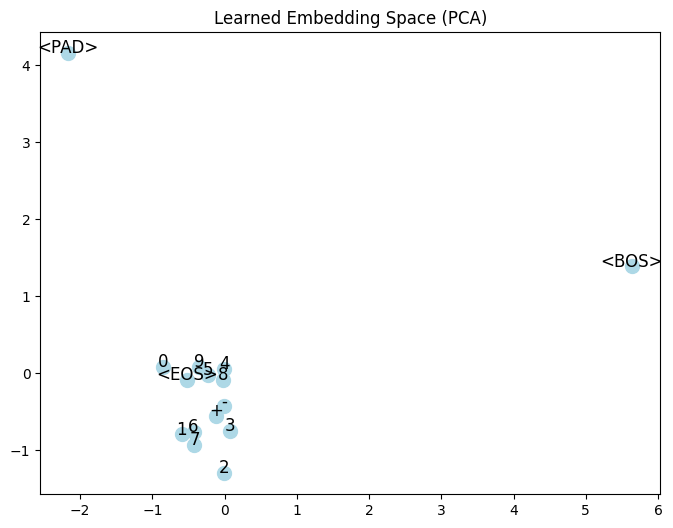

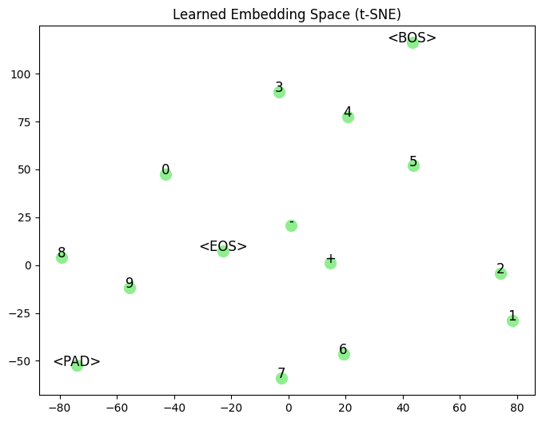

```python
visualize_embeddings(net.encoder, dataset)
visualize_embeddings_tsne(net.encoder, dataset)
```

### Principal Component Analysis (PCA)

**Theory:** PCA is a linear dimensionality reduction technique that identifies the "principal components", which are the directions that account for the most variance in the data. It works by performing an **Eigenvalue Decomposition** or **Singular Value Decomposition (SVD)** on the data’s covariance matrix.

Mathematically, if your embeddings are in a matrix $\mathbf{X}$, PCA finds a projection matrix $\mathbf{W}$ that transforms the data into a lower-dimensional $\mathbf{Z}$: $$\mathbf{Z} = \mathbf{XW}$$

### The PCA Plot

Why are +, -, `<EOS>`, and digits clustered? Because `<PAD/>` and `<BOS>` are massive outliers. `<PAD>` is a dummy token ignored by masks, and `<BOS>` is a rigid anchor always used to start the decoder. Their mathematical roles are so extreme that they dominate the 2D projection. The digits and operators are squashed together simply because, relative to the extremes of `<BOS>` and `<PAD>`, they are mathematically similar (they all represent actual "equation content").

**Summary:** The model has successfully learned to distinguish **Structure** (BOS/PAD) from **Content** (Digits/Operators). PCA highlights that structural tokens are mathematically more "extreme" than the numbers themselves.

### t-SNE: The Theory and Math

**t-distributed Stochastic Neighbor Embedding (t-SNE)** is a non-linear dimensionality reduction technique specifically designed to visualize high-dimensional data by preserving local structures. While PCA tries to keep distant points far apart (global variance), t-SNE focuses on keeping similar points close together.

#### The Mathematical Intuition:

1. **High-Dimensional Similarities:** In the original space (your 32D embeddings), t-SNE converts Euclidean distances between points into conditional probabilities $p_{j|i}$. This represents the likelihood that point $i$ would pick point $j$ as its neighbor if neighbors were picked in proportion to a Gaussian density centered at $i$.
2. **Low-Dimensional Similarities:** In the 2D/3D map, it computes a similar probability $q_{j|i}$ but uses a **Student t-distribution** (which has "fiddly" tails) instead of a Gaussian.
   - *Why?* The t-distribution helps solve the "crowding problem," where points in high dimensions don't have enough "room" to be represented accurately in 2D.
3. **Optimization:** The algorithm minimizes the **Kullback-Leibler (KL) divergence** between the two distributions: $$KL(P \| Q) = \sum_{i} \sum_{j} p_{ij} \log \frac{p_{ij}}{q_{ij}}$$ It effectively "nudges" the points in the 2D plot until the neighborhood relationships match the 32D space as closely as possible.

### The t-SNE Plot

Unlike PCA, t-SNE preserves local distances, pulling apart that squashed cluster. You can see + and - sitting relatively close to each other near the middle, forming a rough "operator" region. The digits are scattered into their own localized pockets, clearly separating the conceptual meaning of numbers from structural tokens.

- **The Operator Cluster:** Look at **`+`** and **`-`**. They are positioned very close to each other near the center-right. This means the model has learned that despite being different operations, they share the same "functional category" as operators that sit between digits.
- **The Number "Manifold":** You can see the digits starting to form a rough circular or "horshoe" pattern (a common t-SNE phenomenon called a manifold).
  - Notice **`8`** and **`9`** are neighbors.
  - Notice **`1`** and **`2`** are neighbors.
  - The model is beginning to understand "numerical proximity". This is the idea that 8 is "like" 9 more than it is like 1.
- **Structural Outliers:** * **`<PAD>`** is way off on the bottom-left. It has no semantic meaning in math, so it is pushed away.
  - **`<BOS>`** is at the top. Since it only ever appears at the start of the decoder sequence, its context is unique, earning it its own isolated corner.
  - **`<EOS>` as the Bridge:** Notice **`<EOS>`** sits in the middle of the digit spread. This makes sense because every number sequence ends with an `<EOS>`, so it shares a relationship with every digit.

**Verdict:** The model has successfully transitioned from "random noise" to "mathematical logic." It has built a mental map where operators, digits, and structural tokens occupy distinct, logical territories.

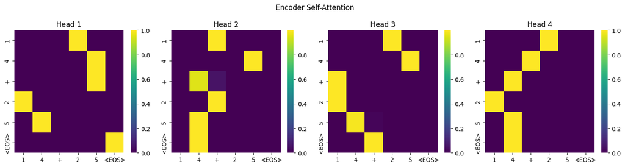

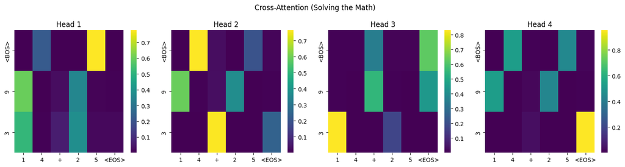

```python
# Test Attention
net.eval()
eq, ans = "14+25", "39"
reversed_ans = ans[::-1]
s_t = list(eq) + ['<EOS>']
ti_t = ['<BOS>'] + list(reversed_ans)
s_tensor = torch.tensor([[dataset.char2idx[c] for c in s_t]]).to(device)
ti_tensor = torch.tensor([[dataset.char2idx[c] for c in ti_t]]).to(device)
vl_tensor = torch.tensor([len(s_t)]).to(device)

with torch.no_grad():
    net(s_tensor, ti_tensor, vl_tensor)


show_attn(net.encoder.attention_weights[-1][0], s_t, s_t, "Encoder Self-Attention")

show_attn(net.decoder.attention_weights[1][-1][0], s_t, ti_t, "Cross-Attention (Solving the Math)")
```

### The Attention Heatmaps

Look specifically at the Cross-Attention (bottom image). In autoregressive generation, the current token on the Y-axis is gathering information to predict the next token (from to to bottom).

### The "Carry-Over" Problem (Left-to-Right)

When we write addition standardly (e.g., 14+25=39), the Decoder must predict the 3 (the tens place) first.

However, in mathematics, you cannot know the tens place for sure until you have calculated the ones place. For example:

- 14+25=39 (No carry)
- 14+26=40 (The ones place 4+6=10 changed the tens place from 3 to 4)

If the model predicts from left-to-right, it has to "guess" if there will be a carry-over before it even generates the ones-place digit. If it guesses wrong, it can't go back and change the first digit it wrote.

#### Matching the Calculation Order

By reversing the target (e.g., 14+25=93), you are forcing the model to predict the ones digit first.

- Step 1: The Decoder predicts 9 (the ones digit). This is easy because it only needs to look at 4+5.
- Step 2: The Decoder now has the 9 in its own memory. When it goes to predict the next digit (3), it knows exactly whether or not it produced a "carry" in the previous step.

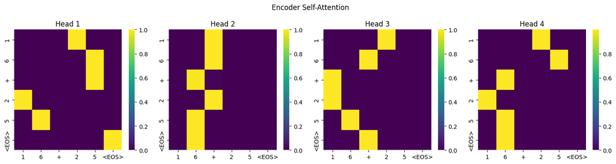

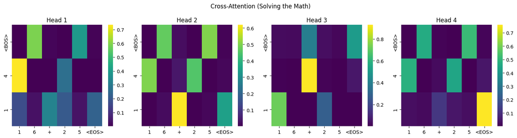

```python
# Test Attention
net.eval()
eq, ans = "16+25", "41"
s_t = list(eq) + ['<EOS>']
ti_t = ['<BOS>'] + list(ans)
s_tensor = torch.tensor([[dataset.char2idx[c] for c in s_t]]).to(device)
ti_tensor = torch.tensor([[dataset.char2idx[c] for c in ti_t]]).to(device)
vl_tensor = torch.tensor([len(s_t)]).to(device)

with torch.no_grad():
    net(s_tensor, ti_tensor, vl_tensor)


show_attn(net.encoder.attention_weights[-1][0], s_t, s_t, "Encoder Self-Attention")

show_attn(net.decoder.attention_weights[1][-1][0], s_t, ti_t, "Cross-Attention (Solving the Math)")
```

```python
def predict_arithmetic(net, equation, dataset, device, max_len=5):
    net.eval()

    tokens = list(equation) + ['<EOS>']
    enc_X = torch.tensor([[dataset.char2idx[c] for c in tokens]], device=device)
    valid_lens = torch.tensor([len(tokens)], device=device)

    enc_outputs = net.encoder(enc_X, valid_lens)
    state = net.decoder.init_state(enc_outputs, valid_lens)

    dec_X = torch.tensor([[dataset.char2idx['<BOS>']]], device=device)
    output_tokens = []

    for _ in range(max_len):
        # forward pass through decoder
        Y, state = net.decoder(dec_X, state)

        # get the highest probability token for the LAST position
        next_token_idx = Y.argmax(dim=-1)[:, -1].item()

        # stop if we hit <EOS>
        if next_token_idx == dataset.char2idx['<EOS>']:
            break

        output_tokens.append(dataset.idx2char[next_token_idx])

        # append predicted token to decoder input for next step
        next_token_tensor = torch.tensor([[next_token_idx]], device=device)
        dec_X = torch.cat((dec_X, next_token_tensor), dim=1)

    return "".join(output_tokens)


def predict_beam_search(net, equation, dataset, device, beam_size=3, max_len=5):
    net.eval()
    tokens = list(equation) + ['<EOS>']
    enc_X = torch.tensor([[dataset.char2idx[c] for c in tokens]], device=device)
    valid_lens = torch.tensor([len(tokens)], device=device)

    enc_outputs = net.encoder(enc_X, valid_lens)
    state = net.decoder.init_state(enc_outputs, valid_lens)

    # each beam: (sequence_indices, cumulative_log_prob, state)
    beams = [([dataset.char2idx['<BOS>']], 0.0, state)]

    for _ in range(max_len):
        new_beams = []
        for seq, score, current_state in beams:
            if seq[-1] == dataset.char2idx['<EOS>']:
                new_beams.append((seq, score, current_state))
                continue

            dec_X = torch.tensor([seq], device=device)
            out, _ = net.decoder(dec_X, current_state)

            # get log probabilities for the last predicted token
            log_probs = torch.log_softmax(out[:, -1, :], dim=-1).squeeze(0)

            # pick top-K candidates
            topk_probs, topk_idxs = torch.topk(log_probs, beam_size)

            for i in range(beam_size):
                new_beams.append((seq + [topk_idxs[i].item()],
                                  score + topk_probs[i].item(),
                                  current_state))

        # sort all candidates by score and keep top-K
        beams = sorted(new_beams, key=lambda x: x[1], reverse=True)[:beam_size]

        # stop if all top beams have ended in <EOS>
        if all(b[0][-1] == dataset.char2idx['<EOS>'] for b in beams):
            break

    # return the best sequence, skipping <BOS> and <EOS>
    best_seq = beams[0][0]
    return "".join([dataset.idx2char[i] for i in best_seq if i not in [dataset.char2idx['<BOS>'], dataset.char2idx['<EOS>']]])
```

```python
test_equations = ["14+25", "99-10", "50+50", "10-20", "11-3", "7+2", "0+0", "0-1", "-1-1"]

print("--- Model Predictions ---")
for eq in test_equations:
    # prediction_greedy = predict_arithmetic(net, eq, dataset, device)
    prediction = predict_beam_search(net, eq, dataset, device)
    print(f"Input: {eq} | Predicted Output: {prediction[::-1]}")
```

```
--- Model Predictions ---
Input: 14+25 | Predicted Output: 39
Input: 99-10 | Predicted Output: 89
Input: 50+50 | Predicted Output: 100
Input: 10-20 | Predicted Output: -10
Input: 11-3 | Predicted Output: -18
Input: 7+2 | Predicted Output: 78
Input: 0+0 | Predicted Output: 0
Input: 0-1 | Predicted Output: -1
Input: -1-1 | Predicted Output: 9
```

# Understanding Beam Search

Beam Search is a heuristic search algorithm used in Seq2Seq models to find the most likely sequence of tokens. It sits between **Greedy Search** (which only considers the single best token) and **Breadth-First Search** (which considers every possible sequence).

## The Core Concept

In a Transformer decoder, we want to find the sequence $\mathbf{y} = (y_1, y_2, ..., y_T)$ that maximizes the conditional probability given an input sequence $\mathbf{x}$:

$$\hat{\mathbf{y}} = \arg \max_{\mathbf{y}} P(y_1, ..., y_T \mid \mathbf{x})$$

Because the vocabulary size $V$ is large, checking every possible sequence ($V^T$) is computationally impossible. Greedy search simplifies this by picking the local optimum at each step $t$:

$$\hat{y}_t = \arg \max_{y \in V} P(y \mid \hat{y}_1, ..., \hat{y}_{t-1}, \mathbf{x})$$

**Beam Search** improves upon this by maintaining a set of $k$ (the "beam width") partial hypotheses at each time step.

## The Mathematics of the Search

### 1. The Log-Probability Objective

Instead of multiplying probabilities (which can lead to numerical underflow), we maximize the sum of log-probabilities. The score for a partial sequence of length $t$ is:

$$s(\mathbf{y}_{1:t}) = \sum_{i=1}^{t} \log P(y_i \mid \mathbf{y}_{1:i-1}, \mathbf{x})$$

### 2. Step-by-Step Expansion

At each time step $t$, for each of the $k$ beams from step $t-1$, we compute the probability for all possible next tokens $y \in V$. This gives us $k \times V$ candidates:

$$\mathcal{C}_t = \{ (\mathbf{y}_{1:t-1}, y) \mid \mathbf{y}_{1:t-1} \in \text{Beams}_{t-1}, y \in V \}$$

We then sort these $k \times V$ candidates by their total log-probability and keep only the top $k$:

$$\text{Beams}_t = \text{Top-k} \left( \{ s(\mathbf{y}_{1:t}) : \mathbf{y}_{1:t} \in \mathcal{C}_t \} \right)$$

### 3. Length Normalization

Standard beam search naturally favors shorter sequences because each additional log-probability (which is negative) decreases the total score. To fix this, we often use a length penalty:

$$\text{Score}(\mathbf{y}) = \frac{1}{L^\alpha} \sum_{i=1}^{L} \log P(y_i \mid \mathbf{y}_{1:i-1}, \mathbf{x})$$

Where:

- $L$ is the current length.
- $\alpha$ is a hyperparameter (usually $0.6$ to $0.7$).

## Why it helps in Arithmetic

In your arithmetic model, the decoder might be 40% sure the first digit is `3` and 38% sure it's `4`.

- **Greedy** picks `3`. If it turns out the answer was actually `40`, the greedy search is permanently stuck on the wrong path.
- **Beam Search** keeps both the `3` and the `4` paths alive. Once it sees the next digit, it can "realize" the `4` path has a much higher total probability and discard the `3` path.

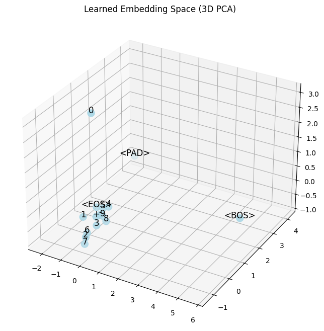

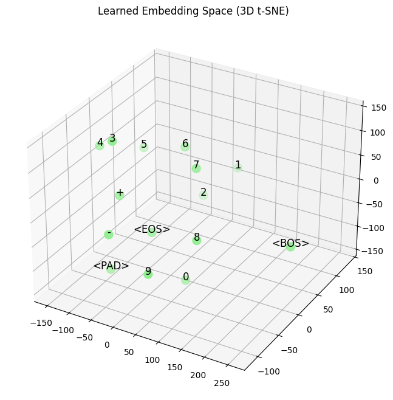

```python
def visualize_embeddings_pca_3d(encoder, dataset):
    pca = PCA(n_components=3)
    embeds = pca.fit_transform(encoder.embedding.weight.detach().cpu().numpy())

    fig = plt.figure(figsize=(10, 8))
    ax = fig.add_subplot(111, projection='3d')
    ax.scatter(embeds[:, 0], embeds[:, 1], embeds[:, 2], c='lightblue', s=100)

    for i, t in dataset.idx2char.items():
        ax.text(embeds[i, 0], embeds[i, 1], embeds[i, 2], t, fontsize=12, ha='center')

    plt.title("Learned Embedding Space (3D PCA)")
    plt.show()

from sklearn.manifold import TSNE

def visualize_embeddings_tsne_3d(encoder, dataset):
    tsne = TSNE(n_components=3, perplexity=5, random_state=42)
    embeds = tsne.fit_transform(encoder.embedding.weight.detach().cpu().numpy())

    fig = plt.figure(figsize=(10, 8))
    ax = fig.add_subplot(111, projection='3d')
    ax.scatter(embeds[:, 0], embeds[:, 1], embeds[:, 2], c='lightgreen', s=100)

    for i, t in dataset.idx2char.items():
        ax.text(embeds[i, 0], embeds[i, 1], embeds[i, 2], t, fontsize=12, ha='center')

    plt.title("Learned Embedding Space (3D t-SNE)")
    plt.show()

visualize_embeddings_pca_3d(net.encoder, dataset)
visualize_embeddings_tsne_3d(net.encoder, dataset)
```